# Session 2 · Lab 2: Stochastic Regression Analysis

From Descriptive Fit to Inferential Reasoning — Classical and Resampling Approaches

Author

Prof. Dr. Jörg Schoder

Published

today

## 1 Scenario & Orientation

In Lab 1 we explored whether the age effect is significant — via bootstrap, permutation, and t-test. The result was not as clear-cut as expected: the t-test said *yes*, the bootstrap CIs were borderline. But we treated `get_regression_table()` as a black box. This lab opens that box.

We start with a fundamental distinction: in Session 1, regression was **descriptive** — we computed the best-fitting line through the data we had. Now we treat that line as an **estimate** of an unknown population relationship. This shift — from conditional mean to conditional expected value — is the conceptual foundation of all statistical inference in regression.

| Phase | Name | Content | Status |
| --- | --- | --- | --- |
| 1 | Business Understanding | Identify under-/overvalued players | Done (Session 1) |
| 2 | Data Understanding | EDA of Bundesliga market values | Done (Session 1) |
| 3 | Data Preparation | log-transform, position dummy | Done (Session 1) |
| 4 | Modelling | OLS: simple + interaction model | Done (Session 1) |
| 5 | Evaluation | Stochastic regression: classical + resampling | ← This lab |
| 6 | Deployment | Transfer decision framework | Session 2 lecture |

**NoteLearning Objectives**

- Distinguish between the **population model** (Level 1: Greek letters), the **estimator** (Level 2: Greek with hat), and the **estimate** (Level 3: Latin letters) — the three levels of the Stocker notation
- Interpret all columns of `get_regression_table()`, `get_regression_summaries()`, and `get_regression_points()` — connecting each to its resampling counterpart from Lab 1
- Use `infer::fit()` to compute bootstrap CIs and permutation p-values for **multiple regression**
- Assess regression assumptions via **residual diagnostics** and understand when resampling is preferable
- Recognise that regression estimates the **conditional mean** — and that this is only one way to model a distribution

**Navigation guide**

| Symbol | Box colour | Meaning | When to read |
| --- | --- | --- | --- |
| ⚠️ | Red | Mandatory task | Live session |
| 💡 | Green | Tip / best practice | Anytime |
| 📚 | Blue (collapsed) | Background theory | At home |
| ℹ️ | Blue (open) | Short clarification | When needed |

**Tip⏱ Time Budget**

**50 minutes** — complete mandatory tasks (A1–A6) first; bonus tasks if time permits.

## 2 Step 1: Population Model vs. Sample Model — The Stocker Notation

The key conceptual shift in this lab is understanding that every fitted regression operates on **three conceptual levels** (following Stocker, *Angewandte Ökonometrie*, Uni Innsbruck).

### Three Levels, Three Notations

| Element | Level 1: Population (unknown) | Level 2: Estimator (random variable) | Level 3: Estimate (realisation) |
| --- | --- | --- | --- |
| Model equation | $$Y_i = \beta_0 + \beta_1 X_i + \varepsilon_i$$ | $$\hat{\beta}_0 + \hat{\beta}_1 X_i + \hat{\varepsilon}_i$$ | $$\hat{y}_i = b_0 + b_1 x_i + e_i$$ |
| Coefficients | $$\beta_0, \beta_1$$ — fixed, unknown | $$\hat{\beta}_0, \hat{\beta}_1$$ — random variables | $$b_0, b_1$$ — computed numbers |
| Error / Residual | $$\varepsilon_i$$ — unobservable | $$\hat{\varepsilon}_i$$ — random variable | $$e_i = y_i - \hat{y}_i$$ — observable |
| Error variance | $$\sigma^2$$ — unknown constant | $$\hat{\sigma}^2 = S^2$$ — random variable | $$s^2 = \frac{\sum e_i^2}{n-k-1}$$ — computed |
| Meaning of line | $$E[Y\|X]$$ (cond. expected value) | Sampling distribution | $$\bar{y}\|x$$ (cond. sample mean) |
| Nature | Constants — one true value | Functions of random sample | Fixed numbers — one per sample |

Level 1 = Greek (unknown); Level 2 = Greek with hat (random); Level 3 = Latin (computed)

The three levels serve different purposes:

- **Level 1 (Population):** What we want to know — the true $\beta_1$. We can never observe it.
- **Level 2 (Estimator):** The *procedure* $\hat{\beta}_1$ that maps any random sample to an estimate. It is a random variable with a distribution (the sampling distribution from Lab 1).
- **Level 3 (Estimate):** The *number* $b_1$ that R reports. It is what `get_regression_table()` shows in the `estimate` column.

**ImportantThe Fundamental Shift**

In Session 1, the regression line was a **description** of the data: the conditional mean $\bar{y}|x$ (Level 3). Now it becomes an **estimate** of the conditional expected value $E[Y|X]$ (Level 1). Same line, different interpretation — and the difference is precisely the uncertainty we quantified via bootstrap in Lab 1. The bootstrap distribution approximates the **Level 2** distribution of $\hat{\beta}_1$.

**Note📚 Background: Why Three Levels, Not Two?**

Many textbooks collapse Levels 2 and 3, writing $\hat{\beta}_1$ for both the estimator and its realisation. Stocker (following Abadir & Magnus, 2002) keeps them separate because the distinction matters conceptually:

- When we say “the standard error of $\hat{\beta}_1$” we refer to the **Level 2** distribution.
- When we say “$b_1 = 0.091$” we refer to the **Level 3** number from our data.
- The statement “$b_1$ is a realisation of $\hat{\beta}_1$” connects the two.

In practice: R reports Level 3 numbers ($b_1$), the SE describes Level 2 variability, and both are used to make inferences about Level 1 ($\beta_1$).

### The Conditional Mean Is Only One Parameter

OLS regression estimates **one feature** of the conditional distribution of $Y|X$: the mean. But a distribution has many other features — spread, shape, tails.

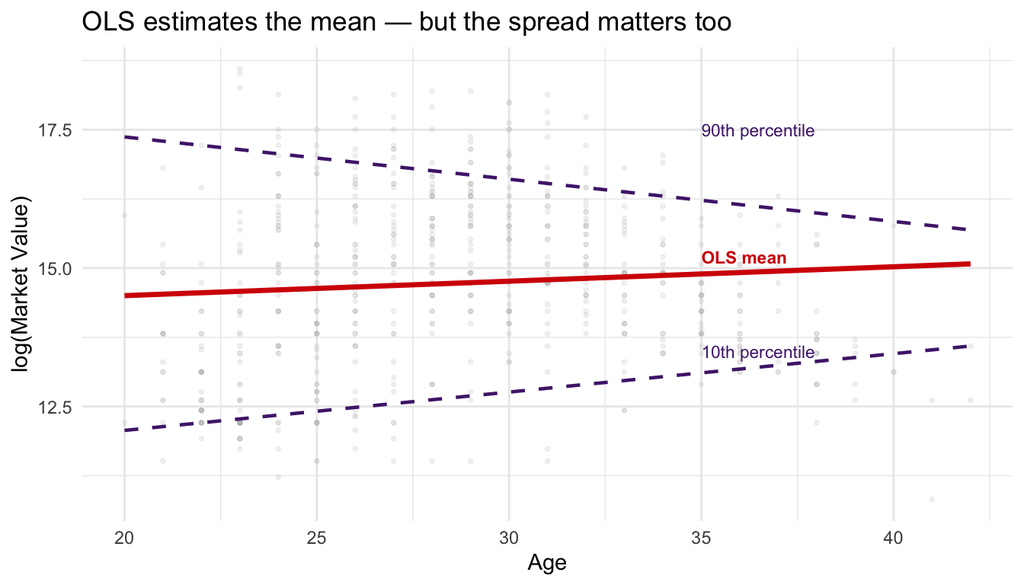

The red line is OLS — the conditional *mean*. The dashed purple lines show the 10th and 90th percentiles of the conditional distribution (via quantile regression). The spread around the mean is not constant — a pattern we will revisit in the residual diagnostics.

**Note📚 Background: Beyond the Mean — Quantile Regression and Beyond**

OLS answers: “What is the *average* market value for a player of age $x$?” But a scout might ask: “What is the market value that only 10% of players of that age exceed?” — that is a question about the *upper tail*, not the mean.

**Quantile regression** (Koenker & Bassett, 1978) estimates conditional *quantiles* instead of the conditional mean. Other approaches model the entire conditional distribution: distributional regression, GAMLSS, or Bayesian methods. These are beyond the scope of ER014, but the key takeaway is: **the mean is a useful summary, but it is not the whole story.** Keep this in mind when interpreting $R^2$ — a low $R^2$ does not mean the model is useless; it means the *mean* does not capture all the variation.

## 3 Step 2: The Classical Toolkit — `lm()` and Three moderndive Helpers

The `moderndive` package provides three functions that extract everything from an `lm()` object in tidy, readable form:

| Function | Returns | Population counterpart |
| --- | --- | --- |
| `get_regression_table()` | $b_j$, SE, t, p, CI | Inference about $\beta_j$ (Level 1 via Level 3) |
| `get_regression_summaries()` | $R^2$, adj. $R^2$, RMSE, F-stat | Model-level fit and global significance |
| `get_regression_points()` | Fitted values $\hat{y}_i$ and residuals $e_i$ | Level 3 counterparts of $\varepsilon_i$ |

### 3.1 2.1 Coefficients: `get_regression_table()`

```r
lm_age <- lm(log_value ~ age, data = tbl_buli)
get_regression_table(lm_age)
```

```
# A tibble: 2 × 7
  term      estimate std_error statistic p_value lower_ci upper_ci
  <chr>        <dbl>     <dbl>     <dbl>   <dbl>    <dbl>    <dbl>
1 intercept   14.0       0.38      36.8    0       13.2     14.7
2 age          0.026     0.013      2.00   0.045    0.001    0.052
```

| term | estimate | std_error | statistic | p_value | lower_ci | upper_ci |
| --- | --- | --- | --- | --- | --- | --- |
| intercept | 13.9810 | 0.3800 | 36.8220 | 0.0000 | 13.2350 | 14.7270 |
| age | 0.0260 | 0.0130 | 2.0050 | 0.0450 | 0.0010 | 0.0520 |

Yellow: age coefficient — each column is explained below

Each column maps to a concept from Lab 1:

| Column | Stocker Level | What it is | Lab 1 counterpart |
| --- | --- | --- | --- |
| `estimate` | 3 | $b_1$ — the computed slope from our sample | `obs_slope` from `calculate(stat = "slope")` |
| `std_error` | 2 | $\text{SE}(\hat{\beta}_1)$ — estimated SD of the sampling distribution | Width of the bootstrap distribution |
| `statistic` | 2→1 | $t = b_1 / \text{SE}(\hat{\beta}_1)$ — how many SEs is $b_1$ from zero? | Position of `obs_slope` relative to null distribution |
| `p_value` | 1 | Prob. of $\|t\|$ this large if $\beta_1 = 0$ | Permutation p-value |
| `lower_ci`, `upper_ci` | 1 | 95% CI for $\beta_1$ using the t-distribution | Bootstrap percentile CI |

The `estimate` column gives a Level 3 number ($b_1$). The `std_error` describes Level 2 variability. Together they enable inference about Level 1 ($\beta_1$).

**Note📚 Background: Where Does the Standard Error Come From?**

The classical SE of the slope coefficient is:

$$\text{SE}(\hat{\beta}_1) = \frac{s}{\sqrt{\sum(x_i - \bar{x})^2}}$$

where $s = \sqrt{\frac{\sum e_i^2}{n - 2}}$ is the residual standard error (a Level 3 estimate of $\sigma$). This formula **assumes** that the errors $\varepsilon_i$ are i.i.d. with constant variance (homoskedasticity). If that assumption fails, the formula gives the wrong SE — and the bootstrap from Lab 1 is more reliable.

Note: the CI uses the t-distribution with $n - 2$ degrees of freedom (not the normal approximation $\pm 1.96$), though for large $n$ the difference is negligible.

### 3.2 2.2 Model-Level Summary: `get_regression_summaries()`

```r
get_regression_summaries(lm_age)
```

```
# A tibble: 1 × 9
  r_squared adj_r_squared   mse  rmse sigma statistic p_value    df  nobs
      <dbl>         <dbl> <dbl> <dbl> <dbl>     <dbl>   <dbl> <dbl> <dbl>
1     0.006         0.005  2.36  1.54  1.54      4.02   0.045     1   634
```

| r_squared | adj_r_squared | mse | rmse | sigma | statistic | p_value | df | nobs |
| --- | --- | --- | --- | --- | --- | --- | --- | --- |
| 0.006 | 0.005 | 2.358 | 1.536 | 1.538 | 4.018 | 0.045 | 1.000 | 634.000 |

Yellow: R² (how much variation explained) and F-statistic (global significance)

| Column | What it is | Interpretation |
| --- | --- | --- |
| `r_squared` | $R^2 = 1 - \text{SSR}/\text{SST}$ | Proportion of variance in $y$ explained by the model |
| `adj_r_squared` | Adjusted for number of predictors | Penalises adding useless predictors |
| `mse` | Mean squared error | Average squared residual |
| `rmse` | $\sqrt{\text{MSE}}$ | Residual standard error $s$ — in the units of $y$ |
| `sigma` | Same as RMSE for simple models | Level 3 estimate of $\sigma$ (population error SD) |
| `statistic` | F-statistic | Global test: are *all* slopes jointly zero? (Lab 1, Step 5.2) |
| `p_value` | p-value for F-test | Significance of the overall model |
| `df` | Degrees of freedom | Number of estimated slope parameters |
| `nobs` | Number of observations | Sample size |

### 3.3 2.3 Fitted Values and Residuals: `get_regression_points()`

```r
reg_points <- get_regression_points(lm_age)
reg_points %>% head(6)
```

```
# A tibble: 6 × 5
     ID log_value   age log_value_hat residual
  <int>     <dbl> <dbl>         <dbl>    <dbl>
1     1      15.8    40          15.0    0.738
2     2      15.4    38          15.0    0.453
3     3      13.5    38          15.0   -1.51
4     4      12.6    23          14.6   -1.97
5     5      18.1    27          14.7    3.45
6     6      17.9    28          14.7    3.20
```

| ID | log_value | age | log_value_hat | residual |
| --- | --- | --- | --- | --- |
| 1 | 15.761 | 40 | 15.024 | 0.738 |
| 2 | 15.425 | 38 | 14.972 | 0.453 |
| 3 | 13.459 | 38 | 14.972 | −1.513 |
| 4 | 12.612 | 23 | 14.581 | −1.969 |
| 5 | 18.133 | 27 | 14.685 | 3.448 |
| 6 | 17.910 | 28 | 14.711 | 3.199 |

Yellow: ŷ (fitted value) and e = y − ŷ (residual) — both are Level 3 quantities

Every row is a player. The `log_value_hat` column is $\hat{y}_i = b_0 + b_1 x_i$ — the model’s prediction (Level 3). The `residual` column is $e_i = y_i - \hat{y}_i$ — the **Level 3 observable counterpart** of the **Level 1 unobservable** disturbance $\varepsilon_i$. It is the basis for all diagnostics in Step 5.

## 4 Step 3: Interpreting SE, t, p, CI — The Bridge to Lab 1

Having seen the three tables, we now connect every classical quantity to its resampling counterpart. The point is not that one is “better” — it is that **they estimate the same underlying quantity**, though they may arrive at slightly different numerical answers, as we saw in Lab 1’s borderline case.

| Classical (parametric) | Resampling (Lab 1) | What it estimates |
| --- | --- | --- |
| SE from formula | SD of bootstrap distribution | Level 2: precision of the estimator β̂₁ |
| t = b₁ / SE(β̂₁) | Position of obs_stat in null distribution | Signal-to-noise ratio |
| p-value from t-distribution | Permutation p-value | Extremity of b₁ under H₀: β₁ = 0 |
| CI from t-distribution | Bootstrap percentile CI | Level 1: plausible range for β₁ |
| F-statistic (get_regression_summaries) | Permutation F-stat (Lab 1, Step 5.3) | Global model significance |

## 5 Step 4: Multiple Regression with `infer::fit()`

In Lab 1 we used `calculate(stat = "slope")` for a single predictor. For the interaction model `log_value ~ age * pos_bin`, we need `fit()` — which returns bootstrap or permutation results for **all coefficients at once**.

### 5.1 4.1 Classical Baseline

```r
lm_inter <- lm(log_value ~ age * pos_bin, data = tbl_buli)
get_regression_table(lm_inter)
```

```
# A tibble: 4 × 7
  term                estimate std_error statistic p_value lower_ci upper_ci
  <chr>                  <dbl>     <dbl>     <dbl>   <dbl>    <dbl>    <dbl>
1 intercept             10.7       0.802     13.3    0        9.11    12.3
2 age                    0.091     0.026      3.45   0.001    0.039    0.142
3 pos_bin: Outfield      3.64      0.896      4.07   0        1.88     5.40
4 age:pos_binOutfield   -0.07      0.03      -2.35   0.019   -0.128   -0.011
```

| term | estimate | std_error | statistic | p_value | lower_ci | upper_ci |
| --- | --- | --- | --- | --- | --- | --- |
| intercept | 10.6830 | 0.8020 | 13.3270 | 0.0000 | 9.1090 | 12.2580 |
| age | 0.0910 | 0.0260 | 3.4470 | 0.0010 | 0.0390 | 0.1420 |
| pos_bin: Outfield | 3.6440 | 0.8960 | 4.0650 | 0.0000 | 1.8830 | 5.4040 |
| age:pos_binOutfield | −0.0700 | 0.0300 | −2.3450 | 0.0190 | −0.1280 | −0.0110 |

Yellow = significant at α = 0.05

### 5.2 4.2 Bootstrap CIs via `fit()`

```r
set.seed(2024)

# --- observed coefficients (Level 3: b values) ---
obs_fit <- tbl_buli %>%
             specify(log_value ~ age * pos_bin) %>%
             fit()

# --- bootstrap (approximates Level 2 distribution of β̂) ---
boot_fit <- tbl_buli %>%
              specify(log_value ~ age * pos_bin) %>%
              generate(reps = 1000, type = "bootstrap") %>%
              fit()

# --- bootstrap CIs (inference about Level 1: β) ---
ci_fit <- boot_fit %>%
            get_confidence_interval(
              point_estimate = obs_fit,
              type           = "percentile",
              level          = 0.95
            )
ci_fit
```

```
# A tibble: 4 × 3
  term                lower_ci upper_ci
  <chr>                  <dbl>    <dbl>
1 age                   0.0453   0.144
2 age:pos_binOutfield  -0.129   -0.0152
3 intercept             9.19    12.0
4 pos_binOutfield       2.08     5.21
```

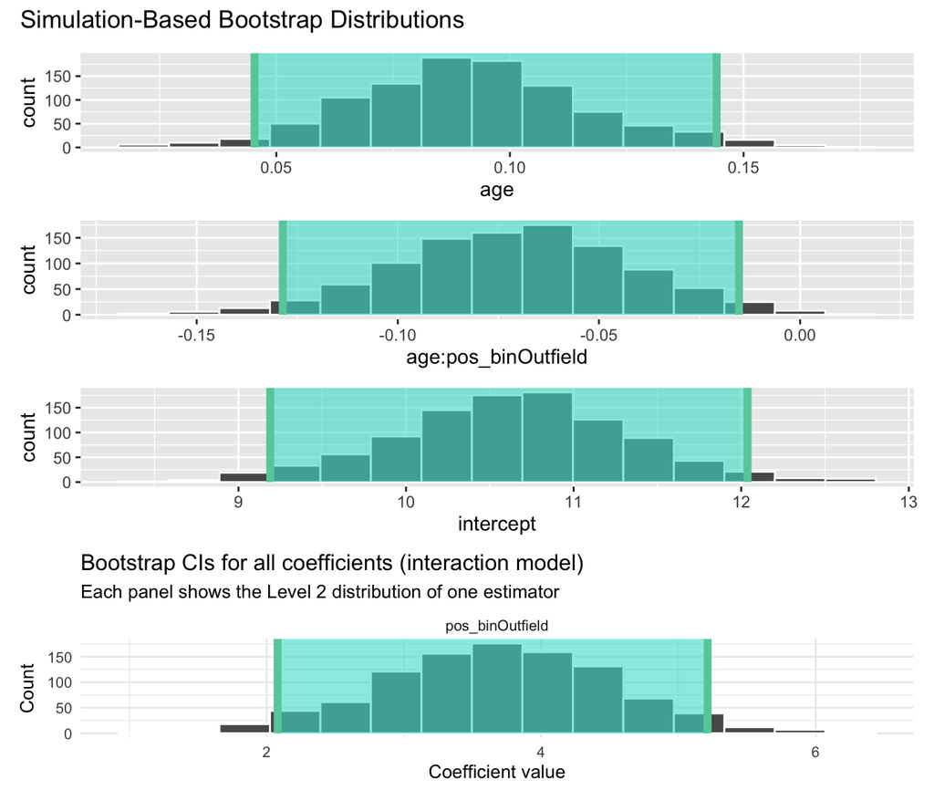

### 5.3 4.3 Permutation Test via `fit()`

```r
set.seed(2024)

null_fit <- tbl_buli %>%
              specify(log_value ~ age * pos_bin) %>%
              hypothesize(null = "independence") %>%
              generate(reps = 1000, type = "permute") %>%
              fit()

p_fit <- null_fit %>%
           get_p_value(obs_stat = obs_fit, direction = "two-sided")
p_fit
```

```
# A tibble: 4 × 2
  term                p_value
  <chr>                 <dbl>
1 age                   0.002
2 age:pos_binOutfield   0.04
3 intercept             0
4 pos_binOutfield       0
```

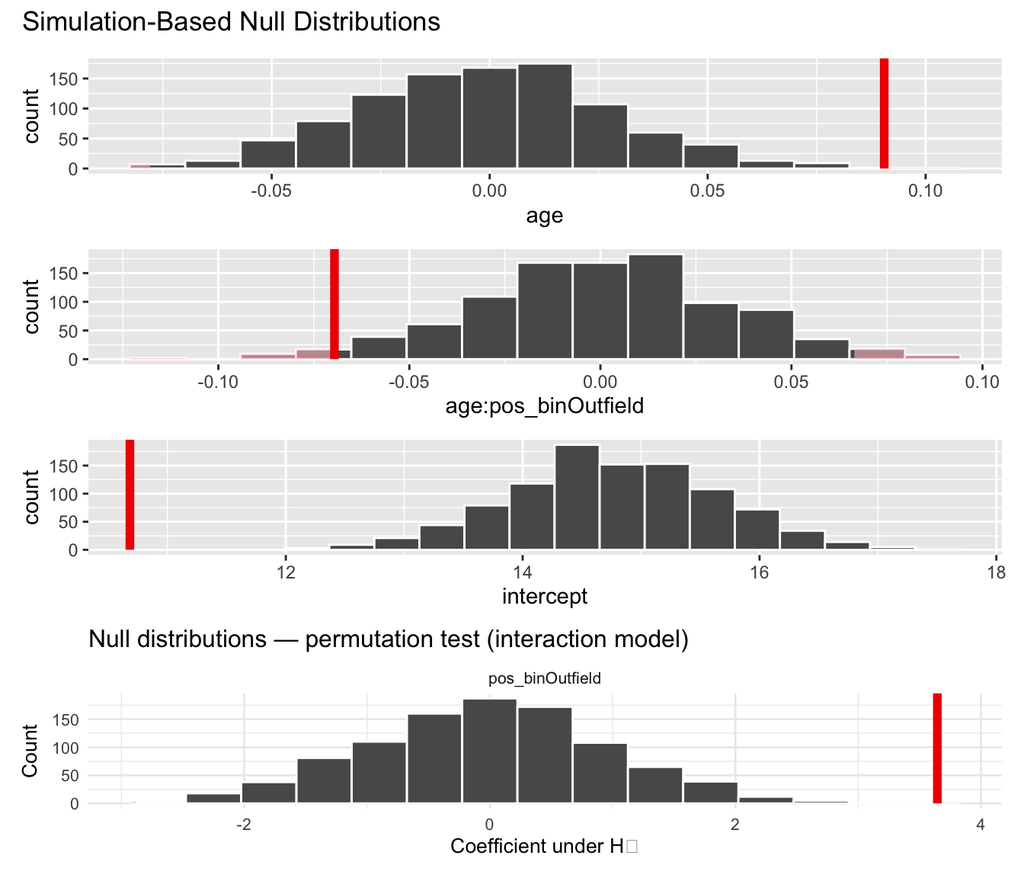

### 4.4 Classical vs. Resampling — Do All Three Methods Agree?

| term | Classical (t-test) lower_ci_trad | Classical (t-test) upper_ci_trad | Classical (t-test) p_trad | Bootstrap / Permutation lower_ci_boot | Bootstrap / Permutation upper_ci_boot | Bootstrap / Permutation p_boot |
| --- | --- | --- | --- | --- | --- | --- |
| intercept | 9.1090 | 12.2580 | 0.0000 | 9.1898 | 12.0379 | 0.0000 |
| age | 0.0390 | 0.1420 | 0.0010 | 0.0453 | 0.1442 | 0.0020 |
| pos_bin: Outfield | 1.8830 | 5.4040 | 0.0000 | 2.0793 | 5.2127 | 0.0000 |
| age:pos_binOutfield | −0.1280 | −0.0110 | 0.0190 | −0.1286 | −0.0152 | 0.0400 |

Green = both methods agree on significance; Yellow = methods disagree

In Lab 1 we asked “three methods, one answer?” — and discovered that the answer is *not always yes*. For the simple age model, the bootstrap CIs barely included zero while the t-test CI did not. Does the interaction model show the same pattern, or do the methods agree more clearly here?

Look at the comparison table. For each coefficient, check whether the classical and bootstrap verdicts match. Where they diverge, recall that three factors can cause discrepancies:

1. The **classical CI** relies on the t-distribution, which assumes normally distributed residuals with constant variance. These are Level 2 assumptions about the distribution of $\hat{\beta}$.
2. The **bootstrap CI** makes no distributional assumptions, but depends on the specific 1,000 resamples drawn. With only 1,000 replicates, the tails of the bootstrap distribution are estimated imprecisely — exactly where borderline significance lives.
3. The **permutation p-value** shuffles the data differently from bootstrap and may push borderline cases across the α = 0.05 threshold.

**ImportantThe Didactic Point**

When a coefficient is clearly significant (e.g. `age`, p ≈ 0.001) or clearly not significant, all methods agree. Discrepancies appear at the **boundary** — for effects that are just barely significant. In such cases:

- Do **not** cherry-pick the method that gives p < 0.05
- Do report both results honestly
- The real question is not “is it significant?” but “is the effect *large enough to matter*?” — which brings us back to the quantile regression plot in Step 1 and the Expected Value Framework in Lab 3

## 6 Step 5: Residual Diagnostics — When Do Classical Assumptions Matter?

The classical formulas for SE, t, p, and CI rest on assumptions about the **Level 1** error term $\varepsilon_i$. We can only check these assumptions through the **Level 3** residuals $e_i$. If these assumptions fail, the formulas may give wrong answers — while bootstrap/permutation remain valid.

The `ggfortify` package provides `autoplot()` which generates the standard four diagnostic plots from an `lm` object in one call:

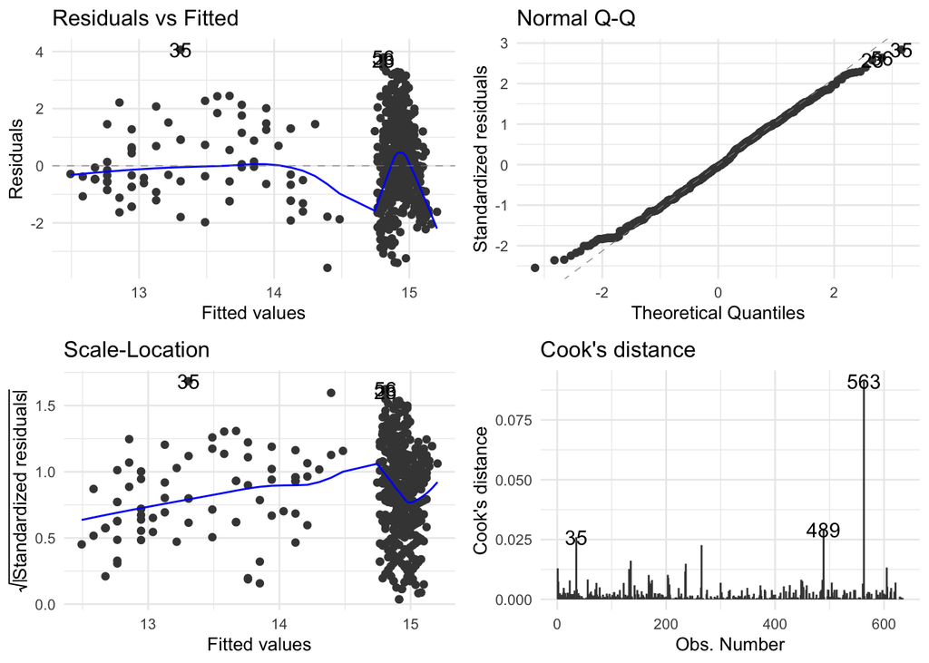

```r
library(ggfortify)
autoplot(lm_inter, which = 1:4, nrow = 2, ncol = 2) +
  theme_minimal(base_size = 10)
```

We now walk through each plot and connect it to the parametric vs. resampling question.

### 6.1 5.1 Residuals vs. Fitted (top left)

Shows residuals $e_i$ against fitted values $\hat{y}_i$. The smoother should be flat if the linearity assumption holds. A curved pattern would suggest that the relationship between $X$ and $E[Y|X]$ is not linear — the Level 1 model is misspecified.

### 6.2 5.2 Normal Q-Q (top right)

Points should follow the diagonal line if $\varepsilon_i \sim N(0, \sigma^2)$ holds. Deviations in the tails are common with real data. Moderate deviations are acceptable for large samples (the CLT protects the t-test). Severe deviations — S-shaped or banana-shaped patterns — indicate that the classical SE formula may give incorrect results, and bootstrap CIs are preferable.

### 6.3 5.3 Scale-Location (bottom left)

Shows $\sqrt{|e_i|}$ against $\hat{y}_i$. If the smoother slopes upward, the error variance is not constant (heteroskedasticity). In that case, the classical SE formula underestimates the true SE for some observations and overestimates it for others. The bootstrap SE remains valid because it does not assume constant variance.

**Note📚 Background: Parametric vs. Nonparametric — and BLUE**

The classical OLS estimator $\hat{\beta}_1$ is **BLUE** — Best Linear Unbiased Estimator — under the Gauss-Markov assumptions (linearity, exogeneity, homoskedasticity, no multicollinearity). “Best” means smallest variance among all linear unbiased estimators.

Importantly, BLUE refers to the **Level 2** property of the estimator $\hat{\beta}_1$, not to any specific Level 3 realisation $b_1$. It says: *if the assumptions hold, no other linear unbiased procedure produces a sampling distribution with smaller spread.*

When these assumptions hold, the parametric SE is more *efficient* (smaller) than the bootstrap SE. When they fail, the parametric SE is *wrong* — and bootstrap is more *honest*.

This is why we always check residual diagnostics: not to decide whether to use regression, but to decide **which standard errors to trust**. We return to BLUE and its implications in Session 3 when we discuss multicollinearity and regularisation.

**NotePractical Rule of Thumb**

| Diagnostics | Recommendation |
| --- | --- |
| Look clean | Use classical SEs — they are more efficient (smaller) |
| Look problematic | Use bootstrap CIs — they are more robust |
| Not sure | Report both — if they agree, the result is solid; if they disagree, trust the bootstrap |

## 7 Mandatory Tasks

**Important⚠️ A1: The Three Stocker Levels**

Look at the notation table in Step 1.

1. In your own words: what is the difference between $\beta_1$ (Level 1), $\hat{\beta}_1$ (Level 2), and $b_1$ (Level 3)?
2. When R reports `estimate = 0.091` in `get_regression_table()` — is that $\beta_1$, $\hat{\beta}_1$, or $b_1$?
3. The bootstrap distribution from Lab 1 approximated the distribution of which level?

**Important⚠️ A2: Reading `get_regression_table()`**

Look at the regression table for `lm_age` in Step 2.1.

1. What does the `std_error` for age tell you? At which Stocker level does it operate? Relate it to the bootstrap distribution from Lab 1.
2. The `statistic` column shows a t-value. What is it — conceptually — and when is it “large enough”?
3. The CI is [0.001, 0.052]. Does it match the bootstrap CI from Lab 1? Why might they differ slightly?

**Important⚠️ A3: Reading `get_regression_summaries()`**

Look at the model summary in Step 2.2.

1. The $R^2$ is 0.006. What does this mean in words?
2. Is a low $R^2$ a reason to discard the model? Consider the quantile regression plot in Step 1.2.
3. What does the F-statistic test? How does it relate to the permutation F-test from Lab 1, Step 5.3?

**Important⚠️ A4: Interaction Model — Do the Methods Agree?**

Look at the comparison table in Step 4.4.

1. For which coefficients do both methods agree on significance?
2. For any coefficient where they disagree (or nearly disagree): what explains the discrepancy? Refer to the three reasons listed in Step 4.4.
3. The interaction term `age:pos_binOutfield` — what does its sign tell you about the age effect for outfield players vs. goalkeepers?
4. Given the diagnostic plots in Step 5: which set of CIs (classical or bootstrap) would you trust more for this model?

Examine the four diagnostic plots in Step 5.

**Important⚠️ A6: The Conditional Mean Is Not Everything**

Look at the quantile regression plot in Step 1.2.

1. What does the gap between the 10th and 90th percentile lines tell you?
2. For a 30-year-old player, roughly how large is the spread between the 10th and 90th percentile of log market value?
3. Why might a scout care more about the upper quantile than the mean?

## 8 Bonus Tasks

**Tip💡 B1: Robust Standard Errors**

The `estimatr` package provides `lm_robust()` which computes heteroskedasticity-consistent (HC) standard errors. Compare:

```r
# install.packages("estimatr")  # if needed
library(estimatr)
lm_robust(log_value ~ age, data = tbl_buli, se_type = "HC2") %>%
  tidy() %>%
  select(term, estimate, std.error, p.value, conf.low, conf.high)
```

How do the HC2 standard errors compare to the classical SEs and the bootstrap SEs?

**Tip💡 B2: Bootstrap for `get_regression_summaries()` Quantities**

Bootstrap the $R^2$ of the simple age model:

```r
set.seed(2024)
boot_r2 <- map_dbl(1:1000, function(i) {
  tbl_buli %>%
    slice_sample(n = nrow(tbl_buli), replace = TRUE) %>%
    lm(log_value ~ age, data = .) %>%
    summary() %>%
    pluck("r.squared")
})
quantile(boot_r2, c(0.025, 0.975))
```

How variable is $R^2$ across samples? Does it ever reach zero?

**Tip💡 B3: Residual Diagnostics for the Simple Model**

Repeat the diagnostic plots from Step 5 for the simple model `lm_age` (without interaction):

```r
autoplot(lm_age, which = 1:4, nrow = 2, ncol = 2) +
  theme_minimal(base_size = 10)
```

Do the diagnostics look better or worse than for the interaction model? What does this tell you about the interaction term’s role?

**Tip💡 B4: Influence Points**

Use `get_regression_points()` to identify the 5 players with the largest absolute residuals. Who are they? Are they potential outliers — or just players that the model cannot explain well?

```r
get_regression_points(lm_inter) %>%
  mutate(abs_resid = abs(residual)) %>%
  arrange(desc(abs_resid)) %>%
  head(5)
```

## 9 Summary

| Finding | Key Result | Implication |
| --- | --- | --- |
| Stocker notation (3 levels) | β (unknown) → β̂ (random) → b (computed) | Every regression output is a Level 3 estimate of a Level 1 parameter |
| get_regression_table() | SE, t, p, CI — all have resampling counterparts | Classical and resampling estimate the same Level 2 quantities |
| get_regression_summaries() | R² = 0.006 | Low R² ≠ useless model; the mean is only one parameter |
| fit() for multiple regression | Bootstrap CIs for all coefficients at once | Scales resampling to any model complexity |
| Classical vs. Resampling | Agree for clear cases; may diverge at the boundary | Borderline results require diagnostic assessment |
| Residual diagnostics | 4 plots via ggfortify::autoplot() | Determines which SEs to trust → BLUE in Session 3 |

**NoteWhat Comes Next**

In **Lab 3** we confront the **multiplicity problem**: when you test many hypotheses at once, false discoveries are inevitable. We simulate p-hacking, apply the Benjamini-Hochberg procedure, and connect everything to the **Expected Value Framework** — because the business decision depends on the *cost* of errors, not just their probability.

**Dataset used:** `buli_raw_2023-09-06.rds` (Bundesliga players, season 2022/23)